# R Notebook

```r
# Read anndata file
library(Seurat)
library(Matrix)
brown_00 <- ReadH5AD(file ="/home/rstudio/time-series/adata/brown_00.h5ad")
brown_15 <- Read10X(data.dir = "/home/rstudio/time-series/umi-counts/brown_15_inex")
brown_10 <- ReadH5AD(file ="/home/rstudio/time-series/adata/brown_10.h5ad")
brown_05 <- ReadH5AD(file ="/home/rstudio/time-series/adata/brown_05.h5ad")
brown_20 <- ReadH5AD(file ="/home/rstudio/time-series/adata/brown_20.h5ad")

bbrown_00=read.table(file = "/home/rstudio/time-series/files/brown_00/barcodes.txt",header = FALSE,sep = "\t")
bbrown_05=read.table(file = "/home/rstudio/time-series/files/brown_05/barcodes.txt",header = FALSE,sep = "\t")
bbrown_10=read.table(file = "/home/rstudio/time-series/files/brown_10/barcodes.txt",header = FALSE,sep = "\t")
bbrown_15=read.table(file = "/home/rstudio/time-series/files/brown_15/barcodes.txt",header = FALSE,sep = "\n")
bbrown_20=read.table(file = "/home/rstudio/time-series/files/brown_20/barcodes.txt",header = FALSE,sep = "\t")

brown_00=subset(brown_00,cells=bbrown_00$V1)
brown_15=brown_15[,bbrown_15$V1]
brown_15=CreateSeuratObject(brown_15)
brown_10=subset(brown_10,cells=bbrown_10$V1)
brown_05=subset(brown_05,cells=bbrown_05$V1)
brown_20=subset(brown_20,cells=bbrown_20$V1)

s_brown=merge(brown_00, y = c(brown_05, brown_10, brown_15, brown_20), add.cell.ids = seq(0,20,5))
s_brown$batch.indices=as.factor(unlist(strsplit(x = colnames(s_brown),split = "_"))[c(TRUE,FALSE)])
s_brown$batch.indices=as.character(s_brown$batch.indices)
s_brown$batch.indices[s_brown$batch.indices==5]="05"
Idents(s_brown)="batch.indices"

# Add latent space
l_brown <- read.csv("/home/rstudio/time-series/latent_space/brown_all_removed_c0v4_genes.csv", row.names=1)
l_brown=as.matrix(l_brown)
rownames(l_brown)=rownames(s_brown@meta.data)
s_brown[["scVI"]] <- CreateDimReducObject(embeddings =l_brown,key = "scVI_")

# Generate UMAP
s_brown=RunUMAP(s_brown,reduction="scVI",dims = 1:10)
library(RColorBrewer)
library(ggplot2)
UMAPPlot(s_brown,label=TRUE,label.size=6,pt.size=1.25,cells.highlight=WhichCells(s_brown,idents = "05"))+theme_void(base_size = 20)

# Normalize data for visualization
s_brown=NormalizeData(s_brown)
```

```r
df=data.frame(s_brown@reductions$umap@cell.embeddings)
df$batch.indices=s_brown$batch.indices
df$batch.indices=as.character(df$batch.indices)
df$batch.indices[df$batch.indices==5]="05"
ggplot(df,aes(x=UMAP_1,y=UMAP_2,color=batch.indices))+geom_point(size=1.25,alpha=.2)+theme_void(base_size = 20)+theme(legend.position = "top")+scale_color_manual(values = brewer.pal(n = 5,name = "Dark2"))
ggsave("/home/rstudio/time-series/figures/brown_integration_with_15/batch.pdf",dpi=72, dev='pdf', height=6, width=8, units="in")
```

```r
UMAPPlot(s_brown,label=TRUE,label.size=6,pt.size=1.25,cells.highlight=WhichCells(s_brown,idents = "0"))+theme_void(base_size = 20)
ggsave("/home/rstudio/time-series/figures/brown_integration_with_15/day00.eps",dpi=72, dev='eps', height=6, width=8, units="in")
```

```r
#  remove nuclei from day 0 high MT and stress response
library(RColorBrewer)
mt.cells=read.table("/home/rstudio/time-series/barcodes/brown_integrated/day.0.high.MT.barcodes.txt", quote="\"", comment.char="")
mt.cells$V1=paste("0",mt.cells$V1,sep="_")

stress.cells=read.table("/home/rstudio/time-series/barcodes/brown_integrated/day.0.unfolded.protein.barcodes.txt", quote="\"", comment.char="")
stress.cells$V1=paste("0",stress.cells$V1,sep="_")

cells=colnames(s_brown)
cells=setdiff(cells,c(mt.cells$V1,stress.cells$V1))

s_brown=subset(s_brown,cells=cells)

UMAPPlot(s_brown,group.by="batch.indices",pt.size=1.25,cols=brewer.pal(n = 5,name = "Dark2"))+theme_void(base_size = 20)+theme(legend.position = "top")
#ggsave("/home/rstudio/time-series/figures/brown_integrated/time-points.eps",dpi=72, dev='eps', height=6, width=8, units="in")
```

```r
# Cluster number 2 contains mitotic cells. My strategy is to remove the subcluster of mitotic cell in cluster # 2 but this would leave some mitotic cells behind (presumably). Confirm that.
# Ans: Confirmed. All mitotic cells are not confined to the cluster alone
# Identify all mitotic cells
brown_05=read.delim(file = "/home/rstudio/time-series/files/brown_05/barcodes.txt",header = FALSE)
brown_05$V1=paste("05",brown_05$V1,sep = "_")
brown_05.mitotic=brown_05$V1[grep("mitotic",brown_05$V2)]

brown_10=read.delim(file = "/home/rstudio/time-series/files/brown_10/barcodes.txt",header = FALSE)
brown_10$V1=paste("10",brown_10$V1,sep = "_")
brown_10.mitotic=brown_10$V1[grep("mitotic",brown_10$V2)]

brown_15=read.delim(file = "/home/rstudio/time-series/files/brown_15/barcodes_state.txt",header = FALSE)
brown_15$V1=paste("15",brown_15$V1,sep = "_")
brown_15.mitotic=brown_15$V1[grep("mitotic",brown_15$V2)]


brown_20=read.delim(file = "/home/rstudio/time-series/files/brown_20/barcodes.txt",header = FALSE)
brown_20$V1=paste("20",brown_20$V1,sep = "_")
brown_20.mitotic=brown_20$V1[grep("mitotic",brown_20$V2)]
mitotic=c(brown_05.mitotic,brown_10.mitotic,brown_15.mitotic,brown_20.mitotic)
UMAPPlot(s_brown,cols=brewer.pal(n = 5,"Set2"),pt.size=1.25,cells.highlight=mitotic)+theme_void(base_size = 20)+theme(legend.position = "top")
```

```r
s_brown=subset(s_brown,cells=setdiff(colnames(s_brown),mitotic))
UMAPPlot(s_brown,group.by="batch.indices",pt.size=1.25,cols=brewer.pal(n = 5,name = "Dark2"))+theme_void(base_size = 20)+theme(legend.position = "top")
```

```r
FeaturePlot(s_brown,"DMD")
FeaturePlot(s_brown,"CACNB2")
s_brown[["percent.mt"]] <- PercentageFeatureSet(s_brown, pattern = "^MT-")
FeaturePlot(s_brown,"percent.mt")
```

```r
s_brown=FindNeighbors(s_brown,reduction="scVI",graph.name="RNA_snn_scVI",dims=1:10)
s_brown=FindClusters(s_brown,resolution = seq(.1, 1.0, by = 0.1),graph.name = "RNA_snn_scVI", verbose = FALSE)

# Visualize cells clustered at different resolutions
library(ggplot2)
p=list(length(seq(.1, 1.0, by = 0.1)))
x=1
for (i in seq(.1, 1.0, by = 0.1)) {
  col.name=colnames(s_brown@meta.data)[match(paste("RNA_snn_scVI_res",i,sep = "."),colnames(s_brown@meta.data))]
  p[[x]]=UMAPPlot(s_brown,group.by=col.name,label=TRUE)+ggtitle(col.name)
  x=x+1
}
library(gridExtra)
n <- length(p)
nCol <- floor(sqrt(n))
#do.call("grid.arrange", c(p, ncol=nCol))
```

```r
Idents(s_brown)="RNA_snn_scVI_res.0.2"
UMAPPlot(s_brown,label=TRUE)
```

```r
seurat_subset=subset(s_brown,cells = WhichCells(object = s_brown,idents = 1))
seurat_subset=FindNeighbors(seurat_subset,reduction="scVI",graph.name="RNA_snn_scVI",dims=1:10)
seurat_subset=FindClusters(seurat_subset,resolution = seq(.1, 1.0, by = 0.1),graph.name = "RNA_snn_scVI", verbose = FALSE)

# Visualize cells clustered at different resolutions
library(ggplot2)
p=list(length(seq(.1, 1.0, by = 0.1)))
x=1
for (i in seq(.1, 1.0, by = 0.1)) {
  col.name=colnames(seurat_subset@meta.data)[match(paste("RNA_snn_scVI_res",i,sep = "."),colnames(seurat_subset@meta.data))]
  p[[x]]=UMAPPlot(seurat_subset,group.by=col.name,label=TRUE)+ggtitle(col.name)
  x=x+1
}
library(gridExtra)
n <- length(p)
nCol <- floor(sqrt(n))
#do.call("grid.arrange", c(p, ncol=nCol))
```

```r
Idents(seurat_subset)="RNA_snn_scVI_res.0.3"
UMAPPlot(seurat_subset,label=TRUE)
```

```r
s_brown$clusters=factor(0,levels = c(0,1,2,3,4,5,6))
s_brown@meta.data[WhichCells(s_brown,idents = 2),"clusters"]=0
s_brown@meta.data[WhichCells(s_brown,idents = 0),"clusters"]=1
s_brown@meta.data[WhichCells(seurat_subset,idents = 3),"clusters"]=2
s_brown@meta.data[WhichCells(seurat_subset,idents = 0),"clusters"]=3
s_brown@meta.data[WhichCells(seurat_subset,idents = 1),"clusters"]=4
s_brown@meta.data[WhichCells(seurat_subset,idents = 2),"clusters"]=5
s_brown@meta.data[WhichCells(seurat_subset,idents = 4),"clusters"]=6
Idents(s_brown)="clusters"
UMAPPlot(s_brown,label=TRUE)
VlnPlot(s_brown,features = c("CACNB2","DMD"),pt.size = 0)
```

```r
s_brown=subset(s_brown,cells = WhichCells(s_brown,idents = 0:4))
UMAPPlot(s_brown,label=TRUE,pt.size=1.25)+theme_void()
ggsave("/home/rstudio/time-series/figures/brown_integration_with_15/cluster.eps",dpi=72, dev='eps', height=6, width=8, units="in")
```

What does the expression of adipogenic markers look like?

```r
library(viridis)
FeaturePlot(s_brown,"ADIPOQ",label=TRUE,label.size=6,pt.size=1.25)+scale_color_viridis_c()+theme_void(base_size = 20)
ggsave("/home/rstudio/time-series/figures/brown_integration_with_15/ADIPOQ.eps",dpi=72, dev='eps', height=6, width=8, units="in")
FeaturePlot(s_brown,"PLIN1",label=TRUE,label.size=6,pt.size=1.25)+scale_color_viridis_c()+theme_void(base_size = 20)
ggsave("/home/rstudio/time-series/figures/brown_integration_with_15/PLIN1.eps",dpi=72, dev='eps', height=6, width=8, units="in")
FeaturePlot(s_brown,"FASN",label=TRUE,label.size=6,pt.size=1.25)+scale_color_viridis_c()+theme_void(base_size = 20)
ggsave("/home/rstudio/time-series/figures/brown_integration_with_15/FASN.eps",dpi=72, dev='eps', height=6, width=8, units="in")
FeaturePlot(s_brown,"ACSL1",label=TRUE,label.size=6,pt.size=1.25)+scale_color_viridis_c()+theme_void(base_size = 20)
ggsave("/home/rstudio/time-series/figures/brown_integration_with_15/ACSL1.eps",dpi=72, dev='eps', height=6, width=8, units="in")
FeaturePlot(s_brown,"GPAM",label=TRUE,label.size=6,pt.size=1.25)+scale_color_viridis_c()+theme_void(base_size = 20)
ggsave("/home/rstudio/time-series/figures/brown_integration_with_15/GPAM.eps",dpi=72, dev='eps', height=6, width=8, units="in")
```

What does the expression of BROWN adipogenic marker genes look like? # NO BROWN MARKER GENE IS ENRICHED IN ADIPOGENIC TRAJECTORY ALONE EXCEPT FOR PPARGC1A AND PPARGC1B WHICH ARE ALSO SHOWN IN TFS BELOW

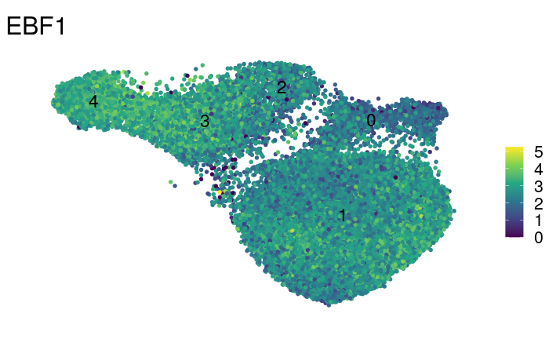

```r
FeaturePlot(s_brown,"EBF1",label=TRUE,label.size=6,pt.size=1.25)+scale_color_viridis_c()+theme_void(base_size = 20)
```

What does the expression of adipogenic TFs look like? Are any preferentially expressed in adipogenic trajectory over non adipogenic? # Yes: PPARG and CEBPA, AND A FEW OTHERS That would mean looking into brown adipogenesis TFs. # DONE

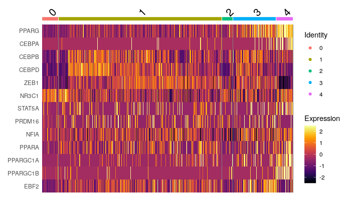

```r
genes=c("PPARG","CEBPA","CEBPB","CEBPD","ZEB1","NR3C1","STAT5A","PRDM16","NFIA","PPARA","PPARGC1A","PPARGC1B","EBF2")
s_brown=ScaleData(s_brown,features = genes)
DoHeatmap(s_brown,features = genes,raster = FALSE)+scale_fill_viridis(option = "B")
ggsave("/home/rstudio/time-series/figures/brown_integration_with_15/adipo.TF.jpeg",dpi=300, dev='jpeg', height=6, width=8, units="in")
```

# BROWN ADIPOGENESIS POSITIVE REGULATORS: https://onlinelibrary-wiley-com.libproxy.berkeley.edu/doi/epdf/10.1002/oby.22334

ESRRA mediates thermogenic response.

[figure not shown]

```r
DoHeatmap(s_brown,features = genes,raster = FALSE)+scale_fill_viridis(option = "B")
```

# BROWN ADIPOGENESIS NEGATIVE REGULATORS

NR1h3 regulates lipid homeostasis.

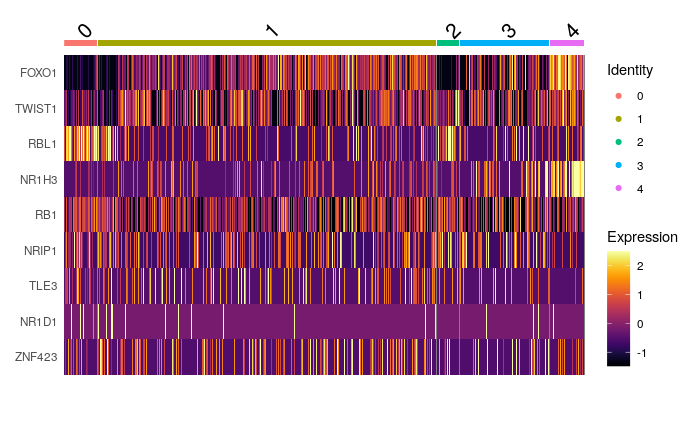

```r
genes=c("FOXO1","TWIST1","RBL1","NR1H3", "RB1", "NRIP1", "TLE3", "NR1D1","ZNF423")
s_brown=ScaleData(s_brown,features = genes)
DoHeatmap(s_brown,features = genes,raster = FALSE)+scale_fill_viridis(option = "B")
```

# Some TFs are activated in non-adipo trajectory whereas others are not. Therefore, the question is what response is illicited in non-adipo trajectory, including TFs, and how is that response different than the one illicited in adipo trajectory?

[figure not shown]

[figure not shown]

The main question I want to answer is if we can molecularly characterize why cells in cluster 1 Theory 1: Cells in cluster 1 are the cells which never initiated adipogenic pathways in respone to IM. But does that mean that they may initiate this pathway after some more time? If they do initiate adipogenic pathway, then how would cells in cluster 1 ever go towards 3,and 4 trajectory. That seems improbable. Moreover, why are all cels from same cluster on day 0 going towards cluster 1. That would mean that somehow the information to initiate adipogenic pathways is already present in one cluster of cells, even before they have seen IM. What are the differences between cluster 0 and cluster 2?

```r
m0=FindMarkers(s_brown,ident.1 = 0,ident.2 = 2,logfc.threshold = .5,only.pos = T)
```

[output not shown]

```r
m2=FindMarkers(s_brown,ident.1 = 2,ident.2 = 0,logfc.threshold = .5,only.pos = T)
```

[output not shown]

```r
write.table(x = rownames(m0),file = "/home/rstudio/time-series/files/brown_integration/filtered.c0v2.txt",sep = "\n",row.names = FALSE,col.names = FALSE,quote = FALSE,eol = "\n")
write.table(x = rownames(m2),file = "/home/rstudio/time-series/files/brown_integration/filtered.c2v0.txt",sep = "\n",row.names = FALSE,col.names = FALSE,quote = FALSE,eol = "\n")
```

```r
FindMarkers(s_brown,ident.1 = 0,ident.2 = 2,logfc.threshold = 0,only.pos = F,features = c("PRRX1","TWIST2","TWIST1","PRRX2","OSR2","MKX","RORB","ZFHX4","ZMAT4","ZNF469"))
```

[output not shown]

|  | p_val | avg_logFC | pct.1 | pct.2 | p_val_adj |
| --- | --- | --- | --- | --- | --- |
| PRRX1 | 3.744185e-87 | -0.46867194 | 0.961 | 0.960 | 1.256623e-82 |
| TWIST2 | 1.965691e-58 | -0.50577397 | 0.922 | 0.916 | 6.597252e-54 |
| ZFHX4 | 1.914282e-56 | 0.25159572 | 0.980 | 0.832 | 6.424713e-52 |
| TWIST1 | 8.131161e-03 | -0.15438872 | 0.846 | 0.747 | 1.000000e+00 |
| PRRX2 | 5.330735e-02 | -0.01183666 | 0.841 | 0.689 | 1.000000e+00 |
| OSR2 | 9.062354e-01 | -0.14055310 | 0.423 | 0.361 | 1.000000e+00 |